# Introduction to Latent Profile Analysis (LPA)

Adam Garber

February 01, 2024

[figure not shown]

[figure not shown]

## An_Introduction_to_LPA_Using_MplusAutomation

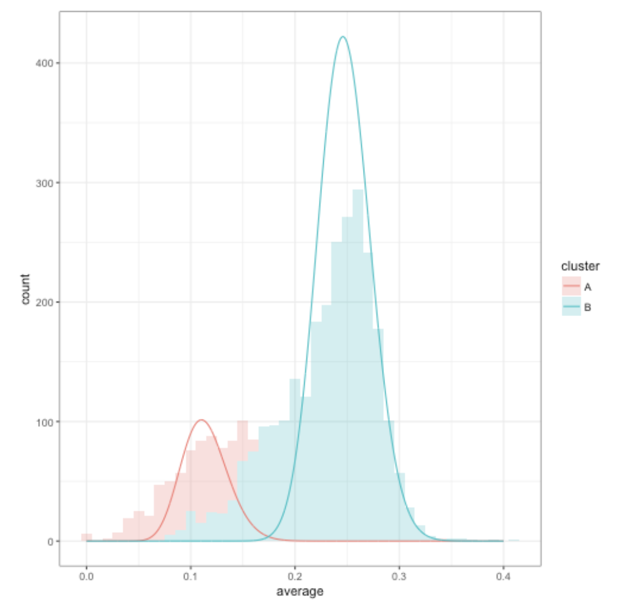

*Figure*. Gaussian mixture models. Data simulated from a 2-class model.

## Preparation

Download repository here: https://github.com/MM4DBER/Intro_to_LPA

Load packages

```r
library(tidyverse)
library(glue)
library(MplusAutomation)
library(here)
library(gt)
library(tidyLPA)
library(patchwork)
```

## Variance-covariance specifications in `LPA`

**Which variance-covariance specification is appropriate?**

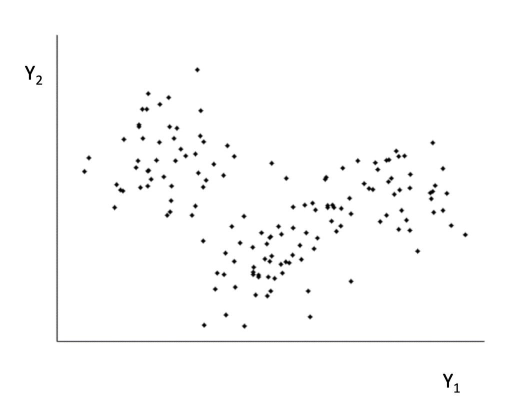

*Figure*. Picture adapted from Masyn (2013)

**The variance-covariance matrix:**

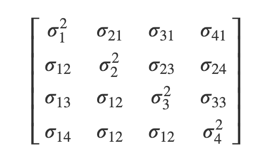

*Figure*. Picture adapted from tutorial (Rosenberg, 2019)

**Terminology for specifying variance-covariance matrix:**

- `Equal variances`: Variances are fixed to equality across class. (i.e., variances are constrained to be equal for each class)
- `Free variances`: Variances parameters are freely estimated across class (i.e., variances vary by class)
- `Covariances fixed to 0`: No covariances are estimated (i.e., the off-diagonal cells of the matrix are zero)
- `Free covariances`: The covariances are freely estimated (e.g., a 4-class model has 6 covariance parameters estimated per class)
- `Equal covariances`: The covariances are fixed to equality across class (i.e., covariances are constrained to be equal across class)

**Model presentation order:**

- Models are presented in the order described in the book chapter by Masyn (2013; p.591).
- An additional model (3a) demonstrates the specification of covariances fixed to equality across class.
- NOTE: Many model specifications are possible. Among variance and covariance parameter groups any combination of these parameters can be freely estimated or fixed.

**Models 1-4 from book chapter in Masyn (2013):**

- `model 1`: Equal variances, and covariances fixed to 0
- `model 2`: Free variances and covariances fixed to 0
- `model 3`: Equal variances, and free covariances
- `model 3a`: Equal variances, and equal covariances (**extra model**)
- `model 4`: Free variances and free covariances

## Example: Math, Science, Physics, and Biology test score measures (LSAY).

**Data source:** The example presented in this tutorial utilizes 4 test score measures (Math, Science, Physics, and Biology) from the public-use data source, *The Longitudinal Survey of American Youth* (**LSAY**): [$\color{blue}{\text{See documentation here}}$](https://www.lsay.org/)

Read in data

```r
lsay_data <- read_csv(here("data", "lsay_lpa.csv"))
```

## `model 1`: Equal variances (fixed) & covariances fixed to zero

In **model-1** the item variances are fixed to equality across latent classes (4 item variances per-class) and covariance parameters are fixed to zero (not estimated). In the applied example, each of the 4 items has a unique variance estimated but the variances are held to equality across each of the latent classes in the example (`4*1= 4 variance parameters`). Relating this to the variance-covariance matrix this model is also named the, **class-invariant, diagonal model**. This is the default model in Mplus. Because it is a relatively parsimonious model it provides a good entry point to begin an LPA analysis.

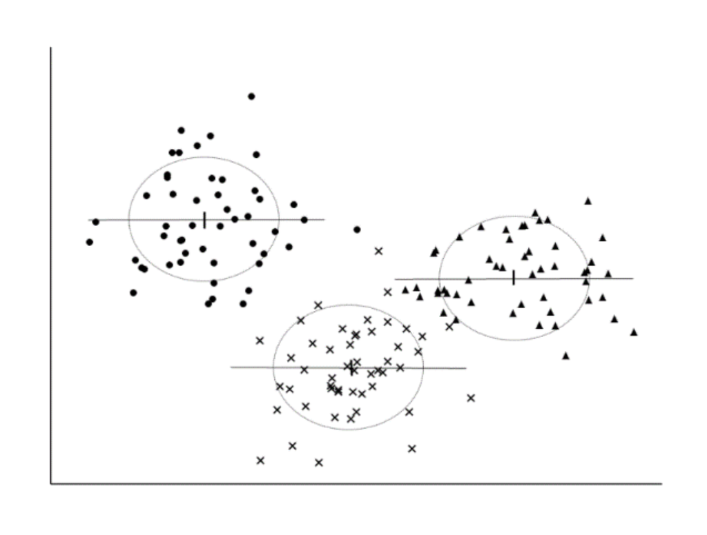

*Figure*. Picture of “diagonal class-invariant model” adapted from Masyn (2013)

**Note:** Model variance-covariance specifications are **stated explicitly** here for pedagogical purposes. `Model 1` can be replicated by removing the syntax under the `MODEL=` command as this is the default specification in Mplus.

```r
lpa_m1  <- lapply(1:6, function(k) {
  z2 <- if_else(k < 2 , '!' , '')
  z3 <- if_else(k < 3 , '!' , '')
  z4 <- if_else(k < 4 , '!' , '')
  z5 <- if_else(k < 5 , '!' , '')
  z6 <- if_else(k < 6 , '!' , '')

lpa_enum  <- mplusObject(

  TITLE = glue("M1: Class{k} "),

  VARIABLE = glue(
   "usevar = mth_scor-bio_scor;
    classes = c({k}); "),

  ANALYSIS =
   "estimator = mlr;
    type = mixture;
    starts = 200 50;
    processors = 10;",

  MODEL = glue(
    "!!!!!!!!!!!!!!!!!!!!!!!!!!!!!!!!!!!!!!!!!!!!!!!!!!!!!!!!!!!!!!!!!!!!!!!!!
     !!!          Syntax replicates default Mplus specification            !!!
     !!!!!!!!!!!!!!!!!!!!!!!!!!!!!!!!!!!!!!!!!!!!!!!!!!!!!!!!!!!!!!!!!!!!!!!!!

     %c#1%
     [mth_scor-bio_scor];     !!! means are are freely estimated  (default)
     mth_scor-bio_scor(1-4);  !!! variances are fixed to equality (default)
                              !!! covariances are fixed to zero   (default)
{z2} %c#2%
{z2} [mth_scor-bio_scor];
{z2} mth_scor-bio_scor(1-4);

{z3} %c#3%
{z3} [mth_scor-bio_scor];
{z3} mth_scor-bio_scor(1-4);

{z4} %c#4%
{z4} [mth_scor-bio_scor];
{z4} mth_scor-bio_scor(1-4);

{z5} %c#5%
{z5} [mth_scor-bio_scor];
{z5} mth_scor-bio_scor(1-4);

{z6} %c#6%
{z6} [mth_scor-bio_scor];
{z6} mth_scor-bio_scor(1-4);"),

  OUTPUT = "sampstat residual tech11 tech14;",

  PLOT =
    "type = plot3;
     series = mth_scor-bio_scor(*);",

  usevariables = colnames(lsay_data),
  rdata = lsay_data)

lpa_m1_fit <- mplusModeler(lpa_enum,
    dataout=glue(here("m1_enum", "c_lpa_m1.dat")),
    modelout=glue(here("m1_enum", "c{k}_lpa_m1.inp")) ,
    check=TRUE, run = TRUE, hashfilename = FALSE)
})
```

Model 1: Produce model fit table

```r
m1_output <- readModels(here("m1_enum"), quiet = TRUE)

m1_enum <- LatexSummaryTable(m1_output,
                keepCols=c("Title","Parameters", "LL", "BIC",
                           "aBIC", "BLRT_PValue", "T11_VLMR_PValue",
                           "Observations"),
                sortBy = "Title")

gt(m1_enum)
```

| Title | Parameters | LL | BIC | aBIC | BLRT_PValue | T11_VLMR_PValue | Observations |
| --- | --- | --- | --- | --- | --- | --- | --- |
| M1: Class1 | 8 | -46288.29 | 92640.89 | 92615.47 | NA | NA | 3103 |
| M1: Class2 | 13 | -43352.36 | 86809.23 | 86767.93 | 0 | 0.0000 | 3103 |
| M1: Class3 | 18 | -42126.11 | 84396.93 | 84339.74 | 0 | 0.0000 | 3103 |
| M1: Class4 | 23 | -41433.72 | 83052.37 | 82979.29 | 0 | 0.0000 | 3103 |
| M1: Class5 | 28 | -41051.51 | 82328.14 | 82239.17 | 0 | 0.1547 | 3103 |
| M1: Class6 | 33 | -40755.99 | 81777.31 | 81672.46 | 0 | 0.0149 | 3103 |

## `model 2`: Free variances & covariances fixed to zero

In **model-2** the variances are freely estimated across latent classes (4 item variances per-class; `4*4=16 variance parameters`) and covariance parameters are fixed to zero. In regards to the variance-covariance matrix this model is also named the, **class-varying, diagonal model**.

```r
lpa_m2  <- lapply(1:6, function(k) {
  z2 <- if_else(k < 2 , '!' , '')
  z3 <- if_else(k < 3 , '!' , '')
  z4 <- if_else(k < 4 , '!' , '')
  z5 <- if_else(k < 5 , '!' , '')
  z6 <- if_else(k < 6 , '!' , '')

lpa_enum  <- mplusObject(

  TITLE = glue("M2: Class{k} "),

  VARIABLE = glue(
   "usevar = mth_scor-bio_scor;
    classes = c({k}); "),

  ANALYSIS =
   "estimator = mlr;
    type = mixture;
    starts = 200 50;
    processors = 10;",

  MODEL = glue(

   "%c#1%
    [mth_scor-bio_scor];   !!! means are are freely estimated
    mth_scor-bio_scor;     !!! variances are freely estimated
                           !!! covariances are fixed to zero (default)
{z2} %c#2%
{z2} [mth_scor-bio_scor];
{z2} mth_scor-bio_scor;

{z3} %c#3%
{z3} [mth_scor-bio_scor];
{z3} mth_scor-bio_scor;

{z4} %c#4%
{z4} [mth_scor-bio_scor];
{z4} mth_scor-bio_scor;

{z5} %c#5%
{z5} [mth_scor-bio_scor];
{z5} mth_scor-bio_scor;

{z6} %c#6%
{z6} [mth_scor-bio_scor];
{z6} mth_scor-bio_scor;

"),

  OUTPUT = "sampstat residual tech11 tech14;",

  PLOT =
    "type = plot3;
     series = mth_scor-bio_scor(*);",

  usevariables = colnames(lsay_data),
  rdata = lsay_data)

lpa_m2_fit <- mplusModeler(lpa_enum,
    dataout=glue(here("m2_enum", "c_lpa_m2.dat")),
    modelout=glue(here("m2_enum", "c{k}_lpa_m2.inp")) ,
    check=TRUE, run = TRUE, hashfilename = FALSE)
})
```

Model 2: Produce model fit table

```r
m2_output <- readModels(here("m2_enum"), quiet = TRUE)

m2_enum <- LatexSummaryTable(m2_output,
                keepCols=c("Title","Parameters", "LL", "BIC",
                           "aBIC", "BLRT_PValue", "T11_VLMR_PValue",
                           "Observations"),
                sortBy = "Title")

gt(m2_enum)
```

| Title | Parameters | LL | BIC | aBIC | BLRT_PValue | T11_VLMR_PValue | Observations |
| --- | --- | --- | --- | --- | --- | --- | --- |
| M2: Class1 | 8 | -46288.29 | 92640.89 | 92615.47 | NA | NA | 3103 |
| M2: Class2 | 17 | -43313.36 | 86763.40 | 86709.38 | 0 | 0.0000 | 3103 |
| M2: Class3 | 26 | -42030.92 | 84270.88 | 84188.27 | 0 | 0.0000 | 3103 |
| M2: Class4 | 35 | -41324.70 | 82930.80 | 82819.59 | 0 | 0.0002 | 3103 |
| M2: Class5 | 44 | -40939.64 | 82233.04 | 82093.24 | 0 | 0.0281 | 3103 |
| M2: Class6 | 53 | -40668.83 | 81763.79 | 81595.38 | 0 | 0.0842 | 3103 |

## `model 3`: Equal (fixed) variances & free covariances

In **model-3** the variances are fixed to equality across latent classes and covariance parameters are freely estimated. In relation to the variance-covariance matrix this model is also named the, **class-invariant, non-diagonal model**. In the example below a total of `4` variance parameters and `24` covariance parameters are estimated (i.e., `6 covariances per-class`). Note that although this example demonstrates a model with all covariances estimated, any number of the covariance (or variance) parameters can be either fixed or freely estimated. For example, 2 item covariances may have substantive meaning while no theoretical precedent exists for estimating the remaining 4 pairwise item covariances.

```r
lpa_m3  <- lapply(1:4, function(k) {
  z2 <- if_else(k < 2 , '!' , '')
  z3 <- if_else(k < 3 , '!' , '')
  z4 <- if_else(k < 4 , '!' , '')

lpa_enum  <- mplusObject(

  TITLE = glue("M3: Class{k} "),

  VARIABLE = glue(
   "usevar = mth_scor-bio_scor;
    classes = c({k}); "),

  ANALYSIS =
   "estimator = mlr;
    type = mixture;
    starts = 200 50;
    processors = 10;",

  MODEL = glue(

   "%c#1%
    [mth_scor-bio_scor];          !!! means are freely estimated
    mth_scor-bio_scor(1-4);       !!! variances are fixed to equality
    mth_scor with sci_scor;       !!! covariances are freely estimated
    mth_scor with phy_scor;
    mth_scor with bio_scor;
    sci_scor with phy_scor;
    sci_scor with bio_scor;
    phy_scor with bio_scor;

{z2} %c#2%
{z2} [mth_scor-bio_scor];
{z2} mth_scor-bio_scor(1-4);
{z2} mth_scor with sci_scor;
{z2} mth_scor with phy_scor;
{z2} mth_scor with bio_scor;
{z2} sci_scor with phy_scor;
{z2} sci_scor with bio_scor;
{z2} phy_scor with bio_scor;

{z3} %c#3%
{z3} [mth_scor-bio_scor];
{z3} mth_scor-bio_scor(1-4);
{z3} mth_scor with sci_scor;
{z3} mth_scor with phy_scor;
{z3} mth_scor with bio_scor;
{z3} sci_scor with phy_scor;
{z3} sci_scor with bio_scor;
{z3} phy_scor with bio_scor;

{z4} %c#4%
{z4} [mth_scor-bio_scor];
{z4} mth_scor-bio_scor(1-4);
{z4} mth_scor with sci_scor;
{z4} mth_scor with phy_scor;
{z4} mth_scor with bio_scor;
{z4} sci_scor with phy_scor;
{z4} sci_scor with bio_scor;
{z4} phy_scor with bio_scor;"),

  OUTPUT = "sampstat residual tech11 tech14;",

  PLOT =
    "type = plot3;
     series = mth_scor-bio_scor(*);",

  usevariables = colnames(lsay_data),
  rdata = lsay_data)

lpa_m3_fit <- mplusModeler(lpa_enum,
    dataout=glue(here("m3_enum", "c_lpa_m3.dat")),
    modelout=glue(here("m3_enum", "c{k}_lpa_m3.inp")) ,
    check=TRUE, run = TRUE, hashfilename = FALSE)
})
```

Model 3: Produce model fit table

```r
m3_output <- readModels(here("m3_enum"), quiet = TRUE)

m3_enum <- LatexSummaryTable(m3_output,
                keepCols=c("Title","Parameters", "LL", "BIC",
                           "aBIC", "BLRT_PValue", "T11_VLMR_PValue",
                           "Observations"),
                sortBy = "Title")

gt(m3_enum)
```

| Title | Parameters | LL | BIC | aBIC | BLRT_PValue | T11_VLMR_PValue | Observations |
| --- | --- | --- | --- | --- | --- | --- | --- |
| M3: Class1 | 14 | -39883.58 | 79879.73 | 79835.24 | NA | NA | 3103 |
| M3: Class2 | 25 | -39769.44 | 79739.87 | 79660.44 | 0 | 0.0000 | 3103 |
| M3: Class3 | 36 | -39724.25 | 79737.94 | 79623.55 | 0 | 0.1976 | 3103 |
| M3: Class4 | 47 | -39688.14 | 79754.17 | 79604.83 | 0 | 0.0322 | 3103 |

## `model 3a`: Equal variances & equal (fixed) covariances

In **model-3a** the variances are fixed to equality across latent classes and covariance parameters are fixed to equality across the 4 latent classes. In-other-words, this model estimates 4 item variances & 6 item covariances. Each unique item has a separate variance estimated and each pairwise covariance has a separate covariance estimated but all the variance-covariance parameters are held to equality across class.

```r
lpa_m3a  <- lapply(1:4, function(k) {
  z2 <- if_else(k < 2 , '!' , '')
  z3 <- if_else(k < 3 , '!' , '')
  z4 <- if_else(k < 4 , '!' , '')

lpa_enum  <- mplusObject(

  TITLE = glue("M3a: Class{k} "),

  VARIABLE = glue(
   "usevar = mth_scor-bio_scor;
    classes = c({k}); "),

  ANALYSIS =
   "estimator = mlr;
    type = mixture;
    starts = 200 50;
    processors = 10;",

  MODEL = glue(

   "%c#1%
    [mth_scor-bio_scor];          !!! means are freely estimated
    mth_scor-bio_scor(1-4);       !!! variances are fixed to equality
    mth_scor with sci_scor(5);    !!! covariances are fixed to equality
    mth_scor with phy_scor(6);
    mth_scor with bio_scor(7);
    sci_scor with phy_scor(8);
    sci_scor with bio_scor(9);
    phy_scor with bio_scor(10);

{z2} %c#2%
{z2} [mth_scor-bio_scor];
{z2} mth_scor-bio_scor(1-4);
{z2} mth_scor with sci_scor(5);
{z2} mth_scor with phy_scor(6);
{z2} mth_scor with bio_scor(7);
{z2} sci_scor with phy_scor(8);
{z2} sci_scor with bio_scor(9);
{z2} phy_scor with bio_scor(10);

{z3} %c#3%
{z3} [mth_scor-bio_scor];
{z3} mth_scor-bio_scor(1-4);
{z3} mth_scor with sci_scor(5);
{z3} mth_scor with phy_scor(6);
{z3} mth_scor with bio_scor(7);
{z3} sci_scor with phy_scor(8);
{z3} sci_scor with bio_scor(9);
{z3} phy_scor with bio_scor(10);

{z4} %c#4%
{z4} [mth_scor-bio_scor];
{z4} mth_scor-bio_scor(1-4);
{z4} mth_scor with sci_scor(5);
{z4} mth_scor with phy_scor(6);
{z4} mth_scor with bio_scor(7);
{z4} sci_scor with phy_scor(8);
{z4} sci_scor with bio_scor(9);
{z4} phy_scor with bio_scor(10);"),

  OUTPUT = "sampstat residual tech11 tech14;",

  PLOT =
    "type = plot3;
     series = mth_scor-bio_scor(*);",

  usevariables = colnames(lsay_data),
  rdata = lsay_data)

lpa_m3a_fit <- mplusModeler(lpa_enum,
    dataout=glue(here("m3a_enum", "c_lpa_m3a.dat")),
    modelout=glue(here("m3a_enum", "c{k}_lpa_m3a.inp")) ,
    check=TRUE, run = TRUE, hashfilename = FALSE)
})
```

Model 3a: Produce model fit table

```r
m3a_output <- readModels(here("m3a_enum"), quiet = TRUE)

m3a_enum <- LatexSummaryTable(m3a_output,
                keepCols=c("Title","Parameters", "LL", "BIC",
                           "aBIC", "BLRT_PValue", "T11_VLMR_PValue",
                           "Observations"),
                sortBy = "Title")

gt(m3a_enum)
```

| Title | Parameters | LL | BIC | aBIC | BLRT_PValue | T11_VLMR_PValue | Observations |
| --- | --- | --- | --- | --- | --- | --- | --- |
| M3a: Class1 | 14 | -39883.58 | 79879.73 | 79835.24 | NA | NA | 3103 |
| M3a: Class2 | 19 | -39821.05 | 79794.86 | 79734.49 | 0 | 0.000 | 3103 |
| M3a: Class3 | 24 | -39776.46 | 79745.89 | 79669.63 | 0 | 0.022 | 3103 |
| M3a: Class4 | 29 | -39745.99 | 79725.14 | 79633.00 | 0 | 0.003 | 3103 |

## `model 4`: Free variances & free covariances

In **model-4** the variances are freely estimated across latent classes (4 item variances per-class; `4*4=16 variance parameters`) and covariance are freely estimated (6 pairwise item covariances per-class; `6*4=24 covariance parameters`). Note that although this example demonstrates a model with all variance/covariance parameters estimated, any number of the covariance (or variance) parameters can be either fixed or freely estimated.

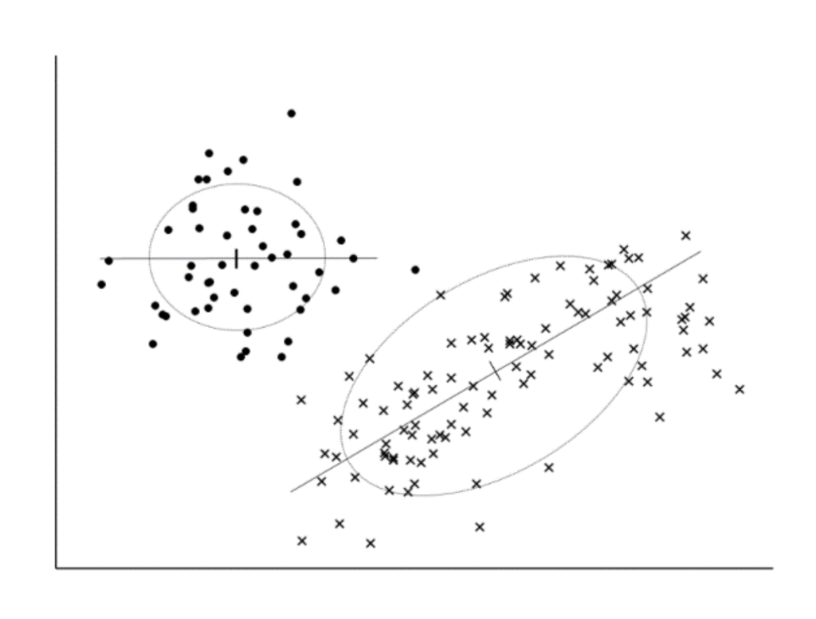

*Figure*. Picture adapted from Masyn (2013)

```r
lpa_m4  <- lapply(1:4, function(k) {
  z2 <- if_else(k < 2 , '!' , '')
  z3 <- if_else(k < 3 , '!' , '')
  z4 <- if_else(k < 4 , '!' , '')

lpa_enum  <- mplusObject(

  TITLE = glue("M4: Class{k} "),

  VARIABLE = glue(
   "usevar = mth_scor-bio_scor;
    classes = c({k}); "),

  ANALYSIS =
   "estimator = mlr;
    type = mixture;
    starts = 200 50;
    processors = 10;",

  MODEL = glue(

   "%c#1%
    [mth_scor-bio_scor];          !!! means are freely estimated
    mth_scor-bio_scor;            !!! variances are freely estimated
    mth_scor with sci_scor;       !!! covariances are freely estimated
    mth_scor with phy_scor;
    mth_scor with bio_scor;
    sci_scor with phy_scor;
    sci_scor with bio_scor;
    phy_scor with bio_scor;

{z2} %c#2%
{z2} [mth_scor-bio_scor];
{z2} mth_scor-bio_scor;
{z2} mth_scor with sci_scor;
{z2} mth_scor with phy_scor;
{z2} mth_scor with bio_scor;
{z2} sci_scor with phy_scor;
{z2} sci_scor with bio_scor;
{z2} phy_scor with bio_scor;

{z3} %c#3%
{z3} [mth_scor-bio_scor];
{z3} mth_scor-bio_scor;
{z3} mth_scor with sci_scor;
{z3} mth_scor with phy_scor;
{z3} mth_scor with bio_scor;
{z3} sci_scor with phy_scor;
{z3} sci_scor with bio_scor;
{z3} phy_scor with bio_scor;

{z4} %c#4%
{z4} [mth_scor-bio_scor];
{z4} mth_scor-bio_scor;
{z4} mth_scor with sci_scor;
{z4} mth_scor with phy_scor;
{z4} mth_scor with bio_scor;
{z4} sci_scor with phy_scor;
{z4} sci_scor with bio_scor;
{z4} phy_scor with bio_scor;"),

  OUTPUT = "sampstat residual tech11 tech14;",

  PLOT =
    "type = plot3;
     series = mth_scor-bio_scor(*);",

  usevariables = colnames(lsay_data),
  rdata = lsay_data)

lpa_m4_fit <- mplusModeler(lpa_enum,
    dataout=glue(here("m4_enum", "c_lpa_m4.dat")),
    modelout=glue(here("m4_enum", "c{k}_lpa_m4.inp")) ,
    check=TRUE, run = TRUE, hashfilename = FALSE)
})
```

Model 4: Produce model fit table

```r
m4_output <- readModels(here("m4_enum"), quiet = TRUE)

m4_enum <- LatexSummaryTable(m4_output,
                keepCols=c("Title","Parameters", "LL", "BIC",
                           "aBIC", "BLRT_PValue", "T11_VLMR_PValue",
                           "Observations"),
                sortBy = "Title")

gt(m4_enum)
```

| Title | Parameters | LL | BIC | aBIC | BLRT_PValue | T11_VLMR_PValue | Observations |
| --- | --- | --- | --- | --- | --- | --- | --- |
| M4: Class1 | 14 | -39883.58 | 79879.73 | 79835.24 | NA | NA | 3103 |
| M4: Class2 | 29 | -39750.04 | 79733.26 | 79641.11 | 0 | 0.0000 | 3103 |
| M4: Class3 | 44 | -39667.68 | 79689.12 | 79549.31 | 0 | 0.0000 | 3103 |
| M4: Class4 | 59 | -39622.03 | 79718.43 | 79530.96 | 0 | 0.0028 | 3103 |

## Final table of model fit (`all models`)

```r
allFit <- rbind(m1_enum,m2_enum,m3_enum,m3a_enum,m4_enum)

allFit1 <- allFit %>%
  mutate(aBIC = -2*LL+Parameters*log((Observations+2)/24)) %>%
  mutate(CAIC = -2*LL+Parameters*(log(Observations)+1)) %>%
  mutate(AWE = -2*LL+2*Parameters*(log(Observations)+1.5)) %>%
  mutate(SIC = -.5*BIC) %>%
  mutate(expSIC = exp(SIC - max(SIC))) %>%
  mutate(BF = exp(SIC-lead(SIC))) %>%
  mutate(cmPk = expSIC/sum(expSIC)) %>%
  select(1:5,9:10,6:7,13,14)
```

Format the model fit table

```r
allFit1 %>%
  mutate(Title = str_remove_all(Title, "M...")) %>%
  gt() %>%
  tab_header(
    title = md("**Model Fit Summary Table**"), subtitle = md("&nbsp;")) %>%
  cols_label(
    Title = "Classes",
    Parameters = md("Par"),
    LL = md("*LL*"),
    T11_VLMR_PValue = "VLMR",
    BLRT_PValue = "BLRT",
    BF = md("BF"),
    cmPk = md("*cmPk*")) %>%
  tab_footnote(
    footnote = md(
    "*Note.* Par = Parameters; *LL* = model log likelihood;
      BIC = Bayesian information criterion;
      aBIC = sample size adjusted BIC; CAIC = consistent Akaike information criterion;
      AWE = approximate weight of evidence criterion;
      BLRT = bootstrapped likelihood ratio test p-value;
      VLMR = Vuong-Lo-Mendell-Rubin adjusted likelihood ratio test p-value;
      *cmPk* = approximate correct model probability."),
    locations = cells_title()) %>%
  tab_options(column_labels.font.weight = "bold") %>%
  fmt_number(10,decimals = 2,
             drop_trailing_zeros=TRUE,
             suffixing = TRUE) %>%
  fmt_number(c(3:9,11),
             decimals = 2) %>%
  sub_missing(1:11,
              missing_text = "--") %>%
  fmt(c(8:9,11),
    fns = function(x)
    ifelse(x<0.001, "<.001",
           scales::number(x, accuracy = 0.01))) %>%
  fmt(10, fns = function(x)
    ifelse(x>100, ">100",
           scales::number(x, accuracy = .1))) %>%
  tab_row_group(
    label = "Model-1",
    rows = 1:6) %>%
  tab_row_group(
    label = "Model-2",
    rows = 7:12) %>%
  tab_row_group(
    label = "Model-3",
    rows = 13:16) %>%
  tab_row_group(
    label = "Model-3a",
    rows = 17:20) %>%
  tab_row_group(
    label = "Model-4",
    rows = 21:24) %>%
  row_group_order(
      groups = c("Model-1","Model-2","Model-3",
                 "Model-3a","Model-4")) %>%
tab_style(style = list(cell_text(weight = "bold")),
  locations = list(
  cells_body(columns = BIC, row = BIC == min(BIC[c(1:6)])),
  cells_body(columns = BIC, row = BIC == min(BIC[c(7:12)])),
  cells_body(columns = BIC, row = BIC == min(BIC[c(13:16)])),
  cells_body(columns = BIC, row = BIC == min(BIC[c(17:20)])),
  cells_body(columns = BIC, row = BIC == min(BIC[c(21:24)])),
  cells_body(columns = aBIC, row = aBIC == min(aBIC[c(1:6)])),
  cells_body(columns = aBIC, row = aBIC == min(aBIC[c(7:12)])),
  cells_body(columns = aBIC, row = aBIC == min(aBIC[c(13:16)])),
  cells_body(columns = aBIC, row = aBIC == min(aBIC[c(17:20)])),
  cells_body(columns = aBIC, row = aBIC == min(aBIC[c(21:24)])),
  cells_body(columns = CAIC, row = CAIC == min(CAIC[c(1:6)])),
  cells_body(columns = CAIC, row = CAIC == min(CAIC[c(7:12)])),
  cells_body(columns = CAIC, row = CAIC == min(CAIC[c(13:16)])),
  cells_body(columns = CAIC, row = CAIC == min(CAIC[c(17:20)])),
  cells_body(columns = CAIC, row = CAIC == min(CAIC[c(21:24)])),
  cells_body(columns = AWE, row = AWE == min(AWE[c(1:6)])),
  cells_body(columns = AWE, row = AWE == min(AWE[c(7:12)])),
  cells_body(columns = AWE, row = AWE == min(AWE[c(13:16)])),
  cells_body(columns = AWE, row = AWE == min(AWE[c(17:20)])),
  cells_body(columns = AWE, row = AWE == min(AWE[c(21:24)])),
  cells_body(columns = cmPk, row =  cmPk > .001),
  cells_body(columns = BF, row =  BF > 10),
  cells_body(columns =  T11_VLMR_PValue,
  row =ifelse(T11_VLMR_PValue < .001 & lead(T11_VLMR_PValue) > .001, T11_VLMR_PValue < .001, NA)),
  cells_body(columns =  BLRT_PValue,
  row =ifelse(BLRT_PValue < .001 & lead(BLRT_PValue) > .001, BLRT_PValue < .001, NA))))
```

**Model Fit Summary Table**<sup>1</sup>

| Classes | Par | *LL* | BIC | aBIC | CAIC | AWE | BLRT | VLMR | BF | *cmPk* |
| --- | --- | --- | --- | --- | --- | --- | --- | --- | --- | --- |
| Model-1 |  |  |  |  |  |  |  |  |  |  |
| Class1 | 8 | −46,288.29 | 92,640.89 | 92,615.47 | 92,648.89 | 92,729.21 | – | – | 0.0 | <.001 |
| Class2 | 13 | −43,352.36 | 86,809.23 | 86,767.93 | 86,822.23 | 86,952.76 | <.001 | <.001 | 0.0 | <.001 |
| Class3 | 18 | −42,126.11 | 84,396.93 | 84,339.74 | 84,414.93 | 84,595.65 | <.001 | <.001 | 0.0 | <.001 |
| Class4 | 23 | −41,433.72 | 83,052.37 | 82,979.29 | 83,075.37 | 83,306.29 | <.001 | <.001 | 0.0 | <.001 |
| Class5 | 28 | −41,051.51 | 82,328.14 | 82,239.17 | 82,356.14 | 82,637.26 | <.001 | 0.15 | 0.0 | <.001 |
| Class6 | 33 | −40,755.99 | 81,777.31 | 81,672.46 | 81,810.31 | 82,141.64 | <.001 | 0.01 | >100 | <.001 |
| Model-2 |  |  |  |  |  |  |  |  |  |  |
| Class1 | 8 | −46,288.29 | 92,640.89 | 92,615.47 | 92,648.89 | 92,729.21 | – | – | 0.0 | <.001 |
| Class2 | 17 | −43,313.36 | 86,763.40 | 86,709.38 | 86,780.40 | 86,951.08 | <.001 | <.001 | 0.0 | <.001 |
| Class3 | 26 | −42,030.92 | 84,270.88 | 84,188.27 | 84,296.88 | 84,557.93 | <.001 | <.001 | 0.0 | <.001 |
| Class4 | 35 | −41,324.70 | 82,930.80 | 82,819.59 | 82,965.80 | 83,317.20 | <.001 | <.001 | 0.0 | <.001 |
| Class5 | 44 | −40,939.64 | 82,233.04 | 82,093.24 | 82,277.04 | 82,718.81 | <.001 | 0.03 | 0.0 | <.001 |
| Class6 | 53 | −40,668.83 | 81,763.79 | 81,595.39 | 81,816.79 | 82,348.92 | <.001 | 0.08 | 0.0 | <.001 |
| Model-3 |  |  |  |  |  |  |  |  |  |  |
| Class1 | 14 | −39,883.58 | 79,879.73 | 79,835.24 | 79,893.73 | 80,034.29 | – | – | 0.0 | <.001 |
| Class2 | 25 | −39,769.44 | 79,739.87 | 79,660.44 | 79,764.88 | 80,015.88 | <.001 | <.001 | 0.4 | <.001 |
| Class3 | 36 | −39,724.25 | 79,737.94 | 79,623.55 | 79,773.94 | 80,135.38 | <.001 | 0.20 | >100 | <.001 |
| Class4 | 47 | −39,688.14 | 79,754.17 | 79,604.83 | 79,801.17 | 80,273.05 | <.001 | 0.03 | >100 | <.001 |
| Model-3a |  |  |  |  |  |  |  |  |  |  |
| Class1 | 14 | −39,883.58 | 79,879.73 | 79,835.24 | 79,893.73 | 80,034.29 | – | – | 0.0 | <.001 |
| Class2 | 19 | −39,821.05 | 79,794.86 | 79,734.49 | 79,813.86 | 80,004.62 | <.001 | <.001 | 0.0 | <.001 |
| Class3 | 24 | −39,776.46 | 79,745.89 | 79,669.63 | 79,769.88 | 80,010.85 | <.001 | 0.02 | 0.0 | <.001 |
| Class4 | 29 | −39,745.99 | 79,725.14 | 79,633.00 | 79,754.14 | 80,045.31 | <.001 | 0.00 | >100 | <.001 |
| Model-4 |  |  |  |  |  |  |  |  |  |  |
| Class1 | 14 | −39,883.58 | 79,879.73 | 79,835.24 | 79,893.73 | 80,034.29 | – | – | 0.0 | <.001 |
| Class2 | 29 | −39,750.04 | 79,733.26 | 79,641.11 | 79,762.25 | 80,053.42 | <.001 | <.001 | 0.0 | <.001 |
| Class3 | 44 | −39,667.68 | 79,689.12 | 79,549.31 | 79,733.12 | 80,174.88 | <.001 | <.001 | >100 | 1.00 |
| Class4 | 59 | −39,622.03 | 79,718.43 | 79,530.96 | 79,777.43 | 80,369.79 | <.001 | 0.00 | – | <.001 |

<sup>1</sup> *Note.* Par = Parameters; *LL* = model log likelihood; BIC = Bayesian information criterion; aBIC = sample size adjusted BIC; CAIC = consistent Akaike information criterion; AWE = approximate weight of evidence criterion; BLRT = bootstrapped likelihood ratio test p-value; VLMR = Vuong-Lo-Mendell-Rubin adjusted likelihood ratio test p-value; *cmPk* = approximate correct model probability.

**Interpreting results:**

For **model-1** the information criteria fit indices (BIC, aBIC, CAIC, AWE) show incremental decreases in the statistic value as class number increases with the minimum value for each IC index at the 6-class model (note; 1-6 class models enumerated). The model comparison tests (BLRT, VLMR, BF, cmPk) show mixed results: The VLMR endorses the 4-class solution while the BLRT, BF, and cmPk are inconclusive. Note, that with the exception of the VLMR the remaining summary statistics are inconclusive at picking a class solution among the 6 models enumerated for this model variance/covariance specification. This is because it is not clear from this table whether a model with a greater number of classes would fit better than the set of solutions shown. This pattern of incremental drop in fit values is not uncommon in LPA/LCA analyses and in this context substantive factors such as the discrimination of the class patterns should also be considered. One common method is to plot the IC values and look for “diminishing returns” in the ICs for each additional class (See figure;Nylund-Gibson & Choi, 2018). However, when looking across variance-covariance models this set of solutions has significantly higher values across all information criteria indicating that the other variance/covariance models have better fit to the data (e.g., `model-2`,…, `model-4`).

**Plot information criteria:**

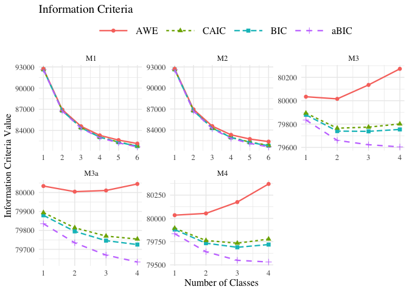

```r
allFit1 %>%
  dplyr::select(1, 4:7) %>%
  rowid_to_column() %>%
  pivot_longer(`BIC`:`AWE`,
               names_to = "Index",
               values_to = "ic_value") %>%
  separate(Title, c('Model', 'Class'), sep = ": Class")  %>%
  mutate(Class = as.numeric(Class)) %>%
  mutate(Index = factor(Index,
                        levels = c ("AWE", "CAIC", "BIC", "aBIC"))) %>%
  ggplot(aes(x = Class, y = ic_value,
    color = Index, shape = Index, group = Index, lty = Index)) +
  facet_wrap(~Model, scales="free") +
  geom_point(size = 2.0) + geom_line(size = .8) +
  scale_x_continuous(breaks = 1:nrow(allFit)) +
  theme_minimal() +
  labs(x = "Number of Classes", y = "Information Criteria Value",
       title = "Information Criteria") +
  theme(text = element_text(family = "serif", size = 12),
    legend.text = element_text(family="serif", size=12),
    legend.key.width = unit(3, "line"), legend.title = element_blank(),
    legend.position = "top")
```

## Plot comparison of `Model-1` and `Model 2` (variances; fixed to equality V. freely estimated):

> The plot on the left illustrates variances constrained to equality across class while the plot on the right has variances which are freely estimated across the 6 classes.

NOTE: The `plotMixtures()` function is used for plotting LPA models only (i.e., means & variances)

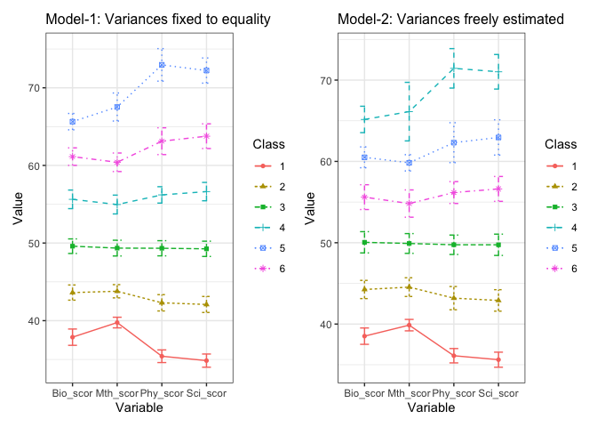

```r
a <- plotMixtures(m1_output$c6_lpa_m1.out,
  ci = 0.95, bw = FALSE)

b <- plotMixtures(m2_output$c6_lpa_m2.out,
  ci = 0.95, bw = FALSE)

a + labs(title = "Model-1: Variances fixed to equality") +
    theme(plot.title = element_text(size = 12)) +
b + labs(title = "Model-2: Variances freely estimated") +
    theme(plot.title = element_text(size = 12))
```

*Figure.* Here we see an ordered solution for model-1 and model-2.

This result might be anticipated given that the correlation between test scores ranges from moderate to high (*r* = .57 - .95).

## Plot conditional means & variances: `Model-4, C=3` (free variances & free covariances)

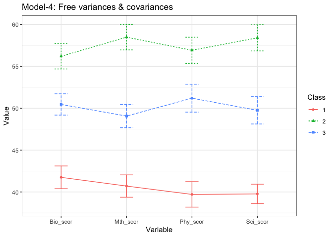

```r
plotMixtures(m4_output$c3_lpa_m4.out, ci = 0.95, bw = FALSE) +
  labs(title = "Model-4: Free variances & covariances")
```

*Figure.* Here we see an ordered solution with variation in item means across each of the four items within-class as well as between-class differences across the 3 classes.

# References

Hallquist, M. N., & Wiley, J. F. (2018). MplusAutomation: An R Package for Facilitating Large-Scale Latent Variable Analyses in Mplus. Structural equation modeling: a multidisciplinary journal, 25(4), 621-638.

Masyn, K. E. (2013). Latent class analysis and finite mixture modeling.

Miller, J. D., Hoffer, T., Suchner, R., Brown, K., & Nelson, C. (1992). LSAY codebook. Northern Illinois University.

Muthén, B. O., Muthén, L. K., & Asparouhov, T. (2017). Regression and mediation analysis using Mplus. Los Angeles, CA: Muthén & Muthén.

Muthén, L.K. and Muthén, B.O. (1998-2017). Mplus User’s Guide. Eighth Edition. Los Angeles, CA: Muthén & Muthén

Rosenberg, J. M., van Lissa, C. J., Beymer, P. N., Anderson, D. J., Schell, M. J. & Schmidt, J. A. (2019). tidyLPA: Easily carry out Latent Profile Analysis (LPA) using open-source or commercial software [R package]. https://data-edu.github.io/tidyLPA/

R Core Team (2017). R: A language and environment for statistical computing. R Foundation for Statistical Computing, Vienna, Austria. URL http://www.R-project.org/

Wickham et al., (2019). Welcome to the tidyverse. Journal of Open Source Software, 4(43), 1686, https://doi.org/10.21105/joss.01686

[figure not shown]